# Cheese

Yara Goldina

2024-06-18

## Introduction

Cheese. Mozzarella, gouda, cheddar, and so many more. Cheese is a diverse and popular product used in cuisine all over the world. There are over one thousand different cheeses around the world. But what exactly makes these cheeses different? And how much variety is there for those with various dietary restrictions?

## Dataset

The dataset used contains 1187 cheeses from cheese.com, with 248 of those having a listed fat content. The variables used include the following:

## Research Questions

- Are there any significant relationships between fat content, milk, and family?
- How do vegetarian cheeses compare to non-vegetarian cheeses?
- How does cheese quantity and fat content compare by country?

## Question 1: Are there any significant relationships between fat content, milk, and family?

The first question of interest has three variables to examine. We start with comparing the fat content of cheeses made from various milks by plotting faceted density histograms. Since some cheeses can be made with different milks and have multiple listed, when examining milks in this project we expanded the data so that a cheese may appear more than once with different milk types.

[output not shown]

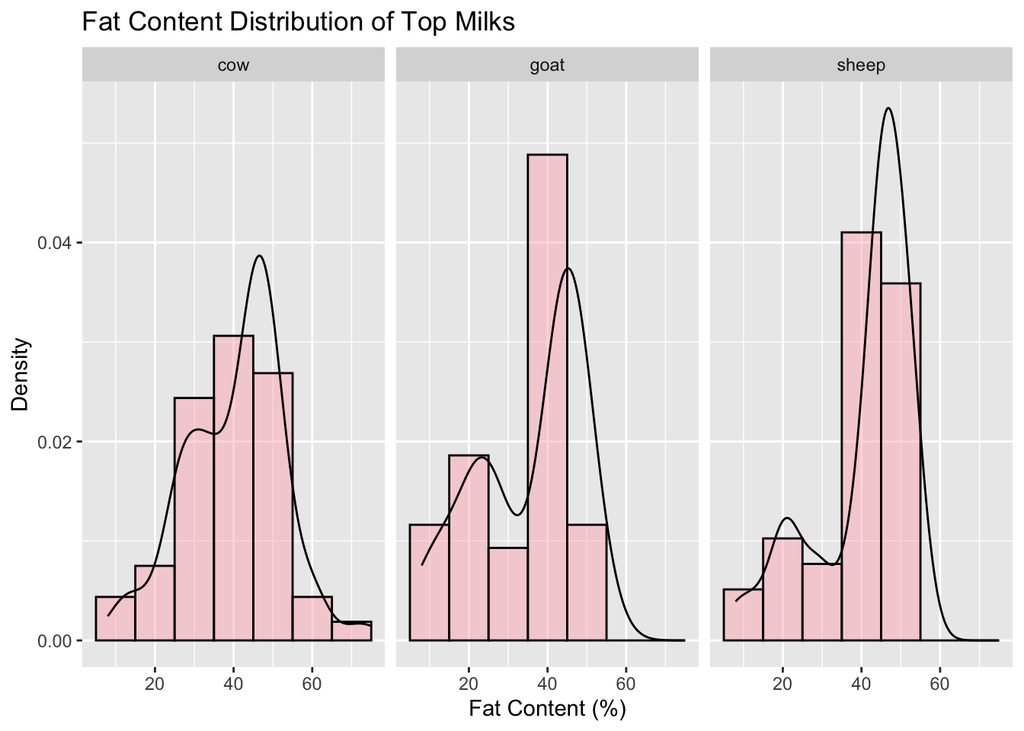

Looking at the distribution of fat content among the top milks, there do not appear to be significant differences. However, to double check this, we run the Kolmogorov-Smirnov test to double check the distributions and ANOVA to check if there is a significant difference in means.

```
##
##  Exact two-sample Kolmogorov-Smirnov test
##
## data:  fat_cow and fat_goat
## D = 0.25932, p-value = 0.0662
## alternative hypothesis: two-sided
```

```
##
##  Exact two-sample Kolmogorov-Smirnov test
##
## data:  fat_cow and fat_sheep
## D = 0.23324, p-value = 0.2313
## alternative hypothesis: two-sided
```

```
##
##  Exact two-sample Kolmogorov-Smirnov test
##
## data:  fat_sheep and fat_goat
## D = 0.32843, p-value = 0.06281
## alternative hypothesis: two-sided
```

```
##              Df Sum Sq Mean Sq F value Pr(>F)
## milk          2    955   477.3   3.063 0.0486 *
## Residuals   239  37242   155.8
## ---
## Signif. codes:  0 '***' 0.001 '**' 0.01 '*' 0.05 '.' 0.1 ' ' 1
## 996 observations deleted due to missingness
```

For every combination of milks, we see that the p-value is above 0.05, and as such we fail to reject the null hypothesis of the distribution of milks being the same. However, our ANOVA result suggests that there is suffient evidence that at least one of the means is significantly different from the others. To look into this further, we run Tukey’s HSD.

```
##   Tukey multiple comparisons of means
##     95% family-wise confidence level
##
## Fit: aov(formula = fat_content ~ milk, data = filt_exp_cheeses)
##
## $milk
##                  diff         lwr         upr     p adj
## goat-cow   -5.0724128 -10.1293781 -0.01544749 0.0491118
## sheep-cow   0.5146474  -4.7427453  5.77204013 0.9710491
## sheep-goat  5.5870602  -0.9228735 12.09699397 0.1086494
```

Here we can see that on average, goat milk has 5.07% less fat than cow milk, sheep milk has 0.51% more fat than cow milk and 5.59% more fat than goat milk. The biggest differences here are those between goat milk and the other two. Looking over to the p-values, we see that the only significant result we have is the difference between goat and cow milk, with adjusted p-value of 0.049 which is less than 0.05. Thus we are able to conclude that there is a significant difference between the means of the fat content of goat milk and cow milk, but none of the other combinations. This brings us to believe that cheeses made with goat milk contain less fat on average than those made with cow milk.

Looking further, we examine the fat content among the top families of cheeses using a density plot.

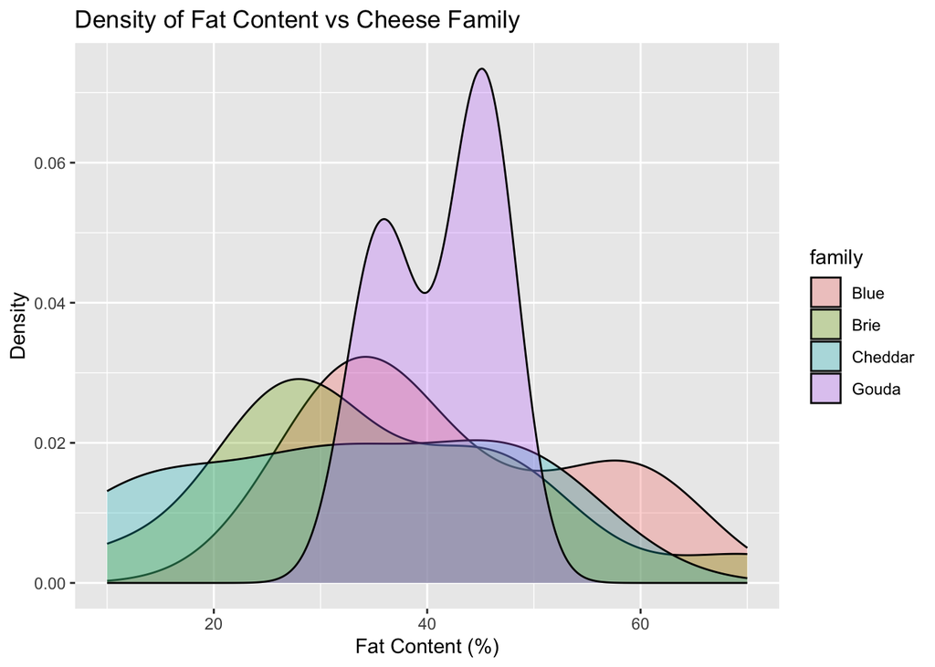

We can see that all of the cheeses have the fat content spread out quite a bit, other than the Gouda cheese which seems to mainly be gathered between 30 and 50%. The peaks appear to be quite different for many of the families, so we use ANOVA once again to check the significance of that.

```
##             Df Sum Sq Mean Sq F value Pr(>F)
## family       3    686   228.8   1.322  0.281
## Residuals   40   6921   173.0
## 242 observations deleted due to missingness
```

The final relationship we have to examine for our first question is family and milk type. To do this, we use a mosaic plot.

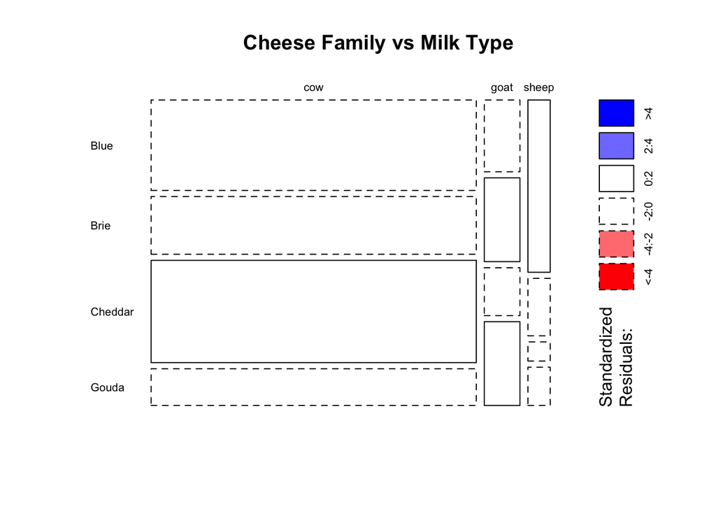

```
##
##  Pearson's Chi-squared test
##
## data:  (milk_fam)
## X-squared = 14.516, df = 6, p-value = 0.02438
```

With these results, we can make the following conclusions to our first question: * Cheeses made with goat milk have less fat than those made with cow milk, on average * There is not enough evidence to conclude that family and fat content affect each other * Milk type has a significant effect on the family of the cheese.

## Question 2: How do vegetarian cheeses compare to non-vegetarian cheeses?

Non-vegetarian cheeses are made using animal rennet, an enzyme that comes from the stomach lining of some animals, which helps curdle the milk. But is there a significant difference in the fat content or milks used? First, we take a look at the distributions of milk based on dietary restriction.

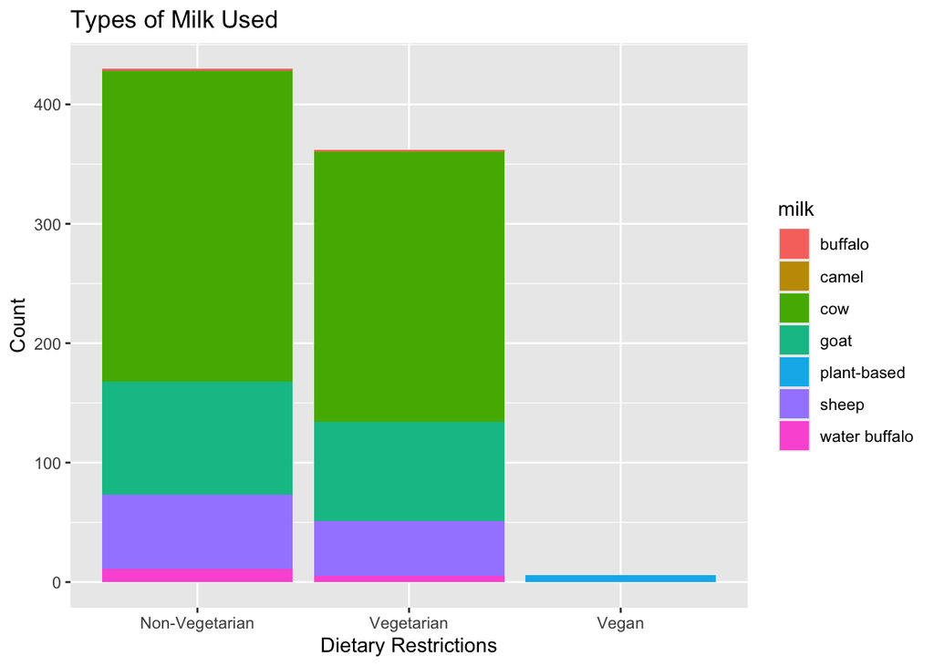

From the stacked bar plot above, we can see the three most used cheeses are cow, goat, and sheep, and they appear to be pretty equally distributed between non-vegetarian and vegetarian cheese. While vegan cheeses are, predictably, made with plant-based milks, we unfortunately only have data on 6 of them and as such will exclude them from this portion of the study.

We start by taking a look at the milk type vs the dietary restrictions of the cheese.

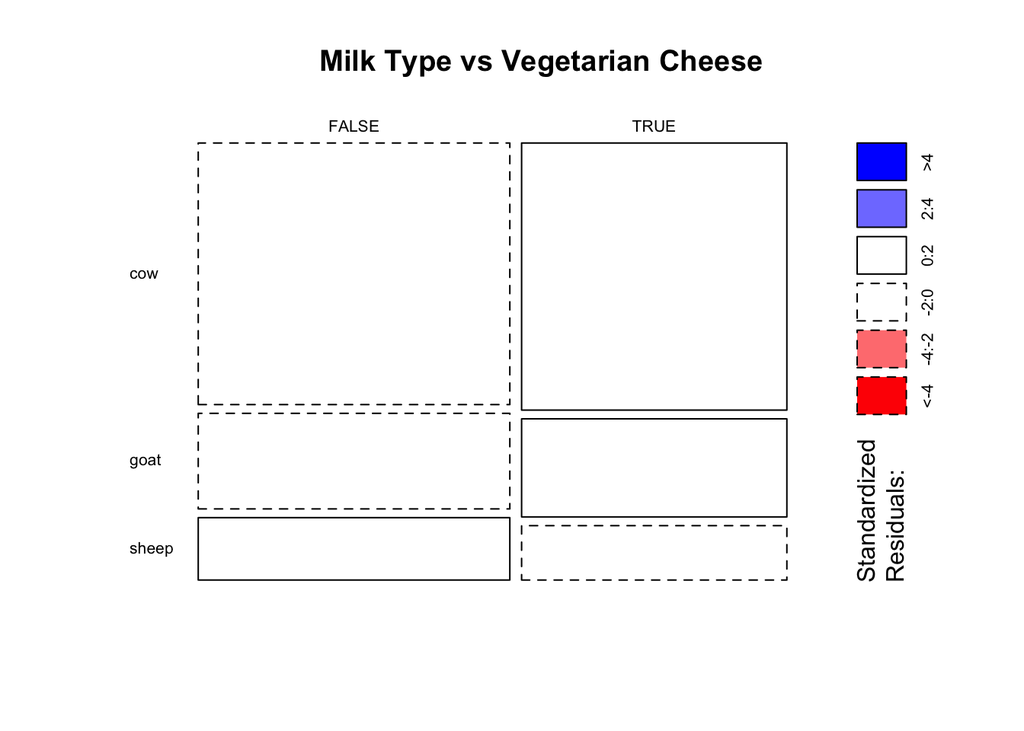

```r
table_milk_veg<- table(filt_exp_cheeses$vegetarian, filt_exp_cheeses$milk )
mosaicplot(table_milk_veg, shade = TRUE, las = 1, main = "Milk Type vs Vegetarian Cheese")
```

```r
chisq.test(table_milk_veg)
```

```
##
##  Pearson's Chi-squared test
##
## data:  table_milk_veg
## X-squared = 0.58244, df = 2, p-value = 0.7474
```

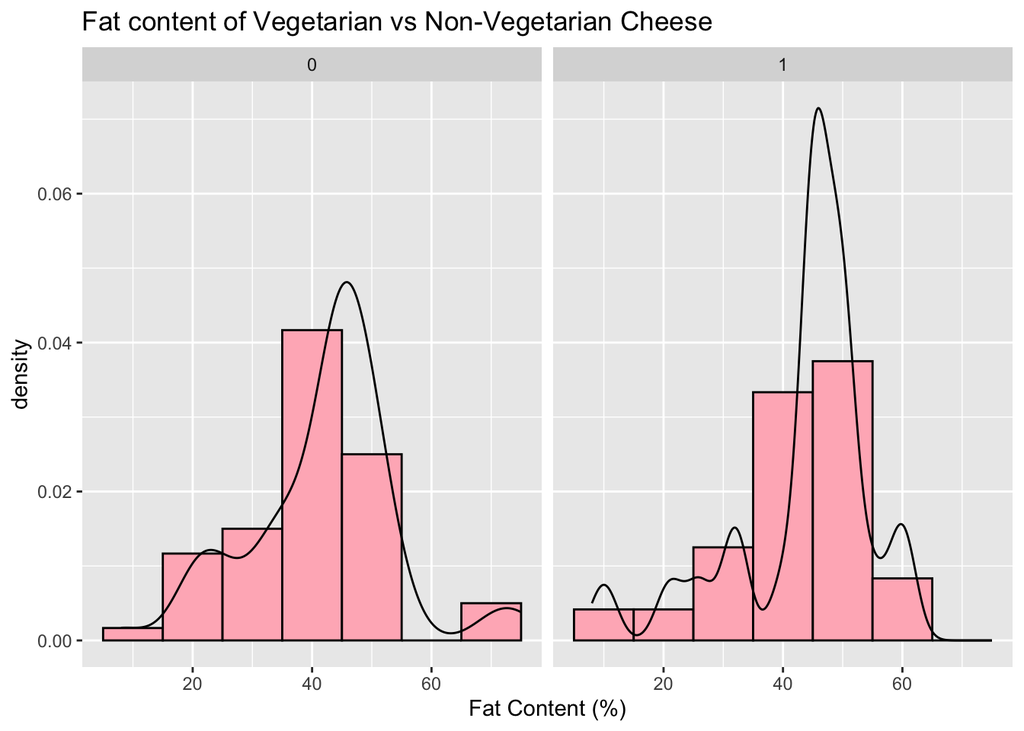

```r
veg_filtered <- filtered_cheeses_diet %>%
  filter(dietary == c(0, 1))
veg_filtered %>%
  ggplot(aes(x = fat_content)) +
  geom_histogram(binwidth = 10, color = "black", fill = "lightpink", aes(y= after_stat(density))) +
  facet_wrap(~dietary) +
  labs(title = "Fat content of Vegetarian vs Non-Vegetarian Cheese",
       x = "Fat Content (%)") +
  geom_density()
```

```r
fat_veg <- filter(cheeses, vegetarian == TRUE)$fat_content
fat_notveg <- filter(cheeses, vegetarian == FALSE)$fat_content

ks.test(fat_veg, fat_notveg)
```

```
##
##  Exact two-sample Kolmogorov-Smirnov test
##
## data:  fat_veg and fat_notveg
## D = 0.14423, p-value = 0.3041
## alternative hypothesis: two-sided
```

```r
t.test(fat_veg, fat_notveg)
```

```
##
##  Welch Two Sample t-test
##
## data:  fat_veg and fat_notveg
## t = 0.76362, df = 111.82, p-value = 0.4467
## alternative hypothesis: true difference in means is not equal to 0
## 95 percent confidence interval:
##  -2.261809  5.098348
## sample estimates:
## mean of x mean of y
##  42.53462  41.11635
```

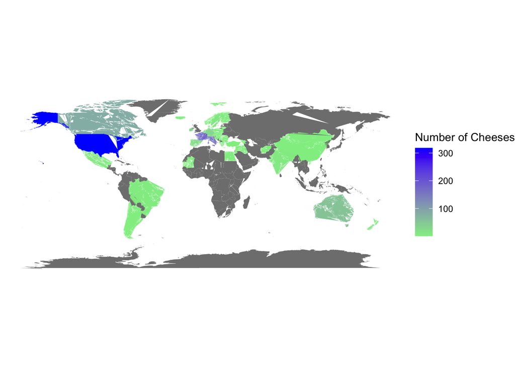

```r
library(maps)
world_map <- map_data("world")

country_cheeses <- cheeses %>%
  separate_rows(country, sep = ",\\s*")

world_map <- world_map %>%
  mutate(region = ifelse(region == "USA", "United States", region))

country_counts <- table(country_cheeses$country)
country_counts <- as.data.frame(country_counts)

merged_cheeses <- merge(world_map, country_counts,
                        by.x = "region", by.y = "Var1", all.x = TRUE)


ggplot(merged_cheeses, aes(x = long, y = lat, group = group, fill = Freq)) +
  geom_polygon() +
  scale_fill_gradient(low = "lightgreen", high = "blue", name = "Number of Cheeses") +
  theme_void() +
  coord_fixed()
```

```r
top_country <- country_cheeses %>%
  count(country, sort = TRUE) %>%
  top_n(4) %>%
  pull(country)
top_country <- country_cheeses %>%
  filter(country %in% top_country)

table_country <- table(top_country$country)
table_country
```

```
##
##         France          Italy United Kingdom  United States
##            176            153             96            318
```

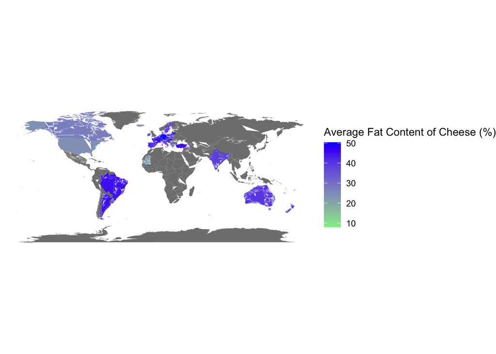

```r
avg_fat <- cheeses %>%
  group_by(country) %>%
  summarise(avg_fat = mean(fat_content, na.rm = TRUE))

merged_cheeses_fat <- merge(world_map, avg_fat,
                        by.x = "region", by.y = "country", all.x = TRUE)

ggplot(merged_cheeses_fat, aes(x = long, y = lat, group = group, fill = avg_fat)) +
  geom_polygon() +
  scale_fill_gradient(low = "lightgreen", high = "blue", name = "Average Fat Content of Cheese (%)") +
  theme_void() +
  coord_fixed()
```

```r
# Croatia
# 50.00000
#
# Hungary
# 50.00000
#
# Lithuania
# 50.00000
#
# Germany
# 50.35714
#
# United Kingdom
# 52.00000
```

remaining questions : would have liked to explore the relationships between calcium content and fat content given more data on calcium

would like to compare vegan as well, but not enough options